# DOC Paper Q Supplement

Author

Alex Cebulski

Published

November 2, 2022

## Overview

Below are plots to be included in the DOC flux paper which uses the 1981-2010 Q norms from Amrit’s regime based calibration on 38 basins in British Columbia. The plots attempt to show the quality of modelled Q through the comparison against observed values. Additional basins were included in this analysis to assess uncalibrated basins and to show performance in the USA.

## Data Sources

Modelled Data

- 1981-2010 monthly runoff normals
- DCWBM with Amrit’s calibration set

Gauged Data

- WSC: tidyhydat r package
- USGS: dataRetreival

Basin Delineations

- WSC: https://collaboration.cmc.ec.gc.ca/cmc/hydrometrics/www/HydrometricNetworkBasinPolygons/
- USGS:
  - https://water.usgs.gov/GIS/dsdl/boundaries_shapefiles_by_aggeco.zip
  - https://water.usgs.gov/GIS/metadata/usgswrd/XML/gagesII_Sept2011.xml

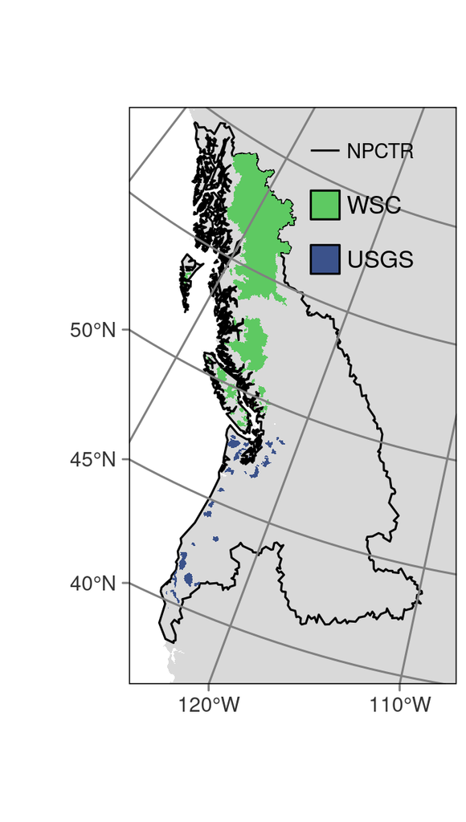

## Annuals

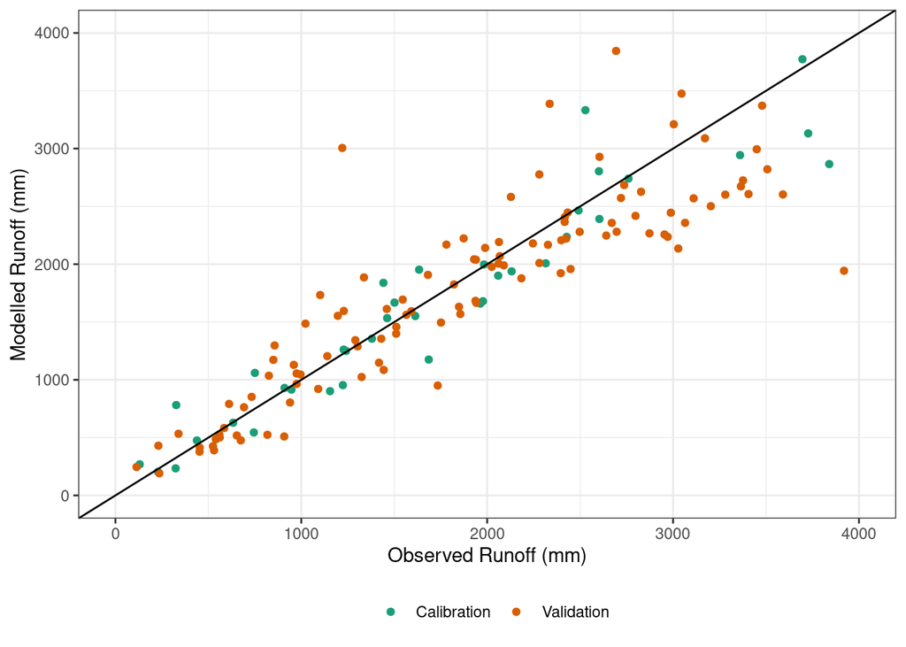

## Annual Statistics

| type | Mean Bias | MAE | RMSE | r_pear | r_spear | nse | n |
| --- | --- | --- | --- | --- | --- | --- | --- |
| Calibration | -67.92 | 228.69 | 319.50 | 0.96 | 0.97 | 0.56 | 38 |
| Validation | -169.79 | 386.12 | 643.63 | 0.87 | 0.92 | 0.32 | 114 |
| All | -144.33 | 346.77 | 579.84 | 0.89 | 0.93 | 0.38 | 152 |

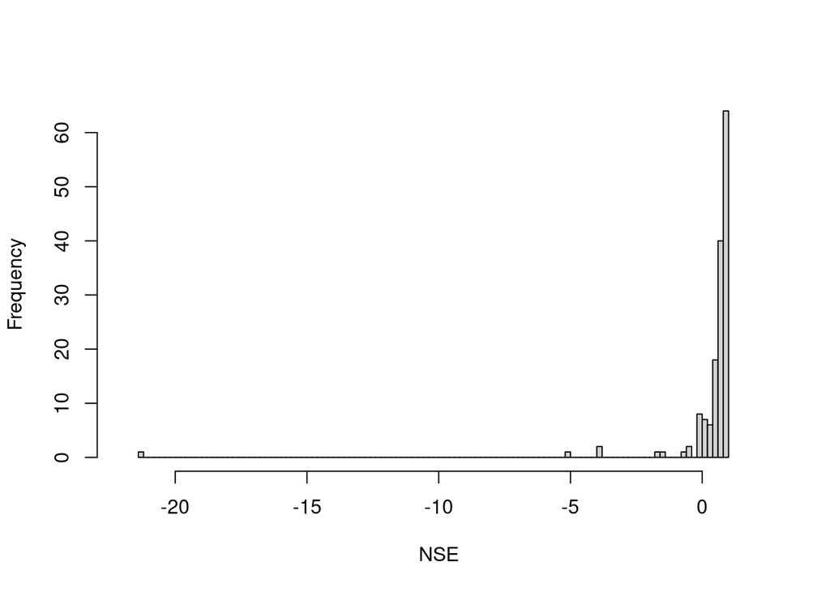

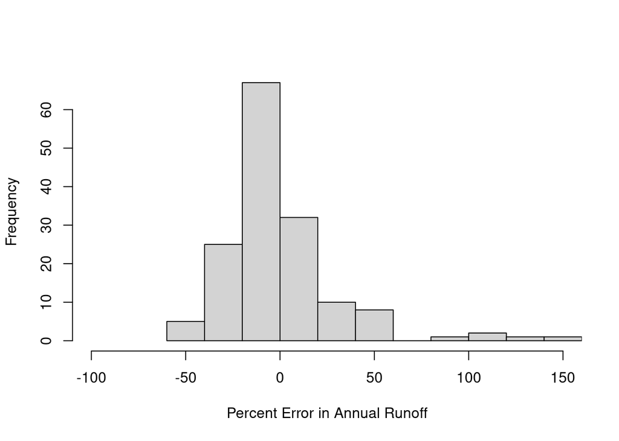

84.8684211% of basins have less than 30% error in annual runoff.

58.5526316% of basins have greater than 0.7 nse.

KIPPAN CREEK NEAR THE MOUTH 1998-2010 BC 08GF005 Flow 51°04’05” N 126°21’30” W 54.3 is the outlier with -20 NSE.

Generally the performance of annual runnoff is better than the seasonal performance.

## Seasonal Hydrograph Plots

Ordered by area, figure headers are gauge id, area (km<sup>2</sup>), NSE.

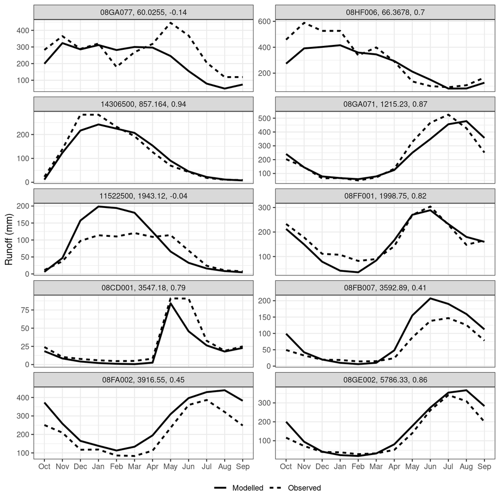

Ordered by NSE, figure headers are gauge id, area (km<sup>2</sup>), NSE.

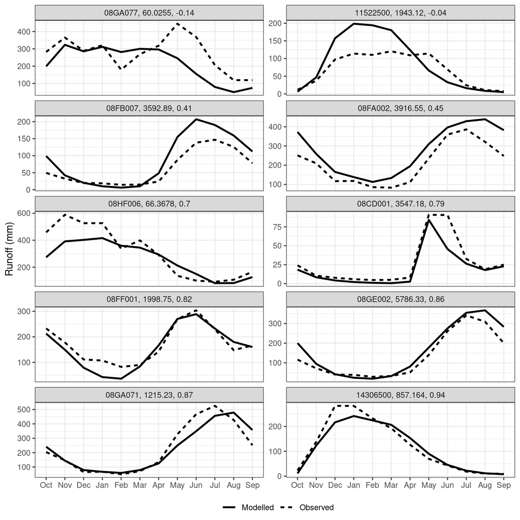

The stats for the above plots are:

| ID | Mean Bias | Max Error | MAE | RMSE | r_pear | r_spear | nse | name | area |
| --- | --- | --- | --- | --- | --- | --- | --- | --- | --- |
| 08GA077 | -56.58 | -213.33 | 78.77 | 103.59 | 0.60 | 0.52 | -0.14 | SEYMOUR RIVER BELOW ORCHID CREEK | 60.0255 |
| 08HF006 | -49.62 | -197.29 | 74.61 | 97.73 | 0.92 | 0.90 | 0.70 | SAN JOSEF RIVER BELOW SHARP CREEK | 66.3678 |
| 14306500 | -6.25 | -66.40 | 17.63 | 25.56 | 0.97 | 0.95 | 0.94 | ALSEA RIVER NEAR TIDEWATER, OR | 857.1640 |
| 08GA071 | -4.37 | -117.97 | 41.92 | 58.09 | 0.94 | 0.94 | 0.87 | ELAHO RIVER NEAR THE MOUTH | 1215.2300 |
| 11522500 | 17.50 | 84.63 | 34.62 | 46.02 | 0.87 | 0.87 | -0.04 | SALMON R A SOMES BAR CA | 1943.1200 |
| 08FF001 | -13.21 | -64.92 | 23.33 | 29.69 | 0.95 | 0.91 | 0.82 | KITIMAT RIVER BELOW HIRSCH CREEK | 1998.7500 |
| 08CD001 | -7.48 | -44.93 | 7.48 | 13.65 | 0.94 | 0.99 | 0.79 | TUYA RIVER NEAR TELEGRAPH CREEK | 3547.1800 |
| 08FB007 | 25.78 | 68.88 | 29.45 | 37.39 | 0.97 | 0.98 | 0.41 | BELLA COOLA RIVER ABOVE BURNT BRIDGE CREEK | 3592.8900 |
| 08FA002 | 67.00 | 134.00 | 67.00 | 76.67 | 0.95 | 0.94 | 0.45 | WANNOCK RIVER AT OUTLET OF OWIKENO LAKE | 3916.5500 |
| 08GE002 | 26.57 | 84.19 | 30.73 | 41.68 | 0.97 | 0.97 | 0.86 | KLINAKLINI RIVER EAST CHANNEL (MAIN) NEAR THE MOUTH | 5786.3300 |

## Monthly Statistics

The stats for the 152 individual basins is shown below.

| ID | Mean Bias | Max Error | MAE | RMSE | r_pear | r_spear | nse | name | area |
| --- | --- | --- | --- | --- | --- | --- | --- | --- | --- |
| 08HA068 | -0.85 | -121.12 | 51.37 | 66.15 | 0.92 | 0.94 | 0.83 | GARBAGE CREEK NEAR THE MOUTH | 2.3022 |
| 08HB069 | -16.77 | -116.89 | 38.80 | 51.73 | 0.96 | 0.97 | 0.89 | CARNATION CREEK AT 150 M CONTOUR | 2.4633 |
| 08GA065 | -45.07 | -154.29 | 47.97 | 67.33 | 0.96 | 0.94 | 0.79 | NOONS CREEK AT MERIDIAN SUBSTATION ROAD | 2.7279 |
| 08GA061 | -24.79 | -117.37 | 28.50 | 44.84 | 0.95 | 0.94 | 0.82 | MACKAY CREEK AT MONTROYAL BOULEVARD | 2.8683 |
| 08FF006 | -164.70 | -407.19 | 164.70 | 204.74 | 0.63 | 0.68 | -0.75 | RENEGADE CREEK NEAR KITIMAT | 5.5395 |
| 08HA026 | 16.17 | 30.68 | 16.17 | 19.07 | 0.99 | 0.99 | 0.64 | CUSHEON CREEK AT OUTLET OF CUSHEON LAKE | 8.4177 |
| 08EE028 | -24.45 | -89.55 | 24.45 | 35.59 | 0.95 | 0.99 | 0.69 | STATION CREEK ABOVE DIVERSIONS | 10.0341 |
| 08HB048 | -2.21 | -127.54 | 45.05 | 54.93 | 0.94 | 0.96 | 0.87 | CARNATION CREEK AT THE MOUTH | 10.0485 |
| 08HA069 | -269.27 | -747.97 | 269.27 | 367.76 | 0.88 | 0.91 | 0.06 | RENFREW CREEK NEAR PORT RENFREW | 10.1799 |
| 08HA072 | 32.41 | 163.28 | 36.99 | 59.91 | 0.87 | 0.87 | 0.55 | COTTONWOOD CREEK HEADWATERS | 12.9609 |
| 08HE008 | 95.92 | 300.15 | 102.80 | 137.46 | 0.82 | 0.88 | -0.15 | ZEBALLOS RIVER AT MOOK PEAK | 13.0383 |
| 08EE012 | -0.37 | -43.17 | 13.10 | 18.33 | 0.96 | 0.96 | 0.90 | SIMPSON CREEK AT THE MOUTH | 13.1787 |
| 08EG017 | -29.87 | -88.57 | 38.28 | 47.28 | 0.75 | 0.69 | -0.18 | DEEP CREEK ABOVE RESERVOIR | 13.5252 |
| 12147600 | -38.00 | -126.18 | 70.02 | 82.93 | 0.80 | 0.67 | 0.54 | SOUTH FORK TOLT RIVER NEAR INDEX, WA | 14.1264 |
| 12073500 | 14.99 | 55.66 | 26.56 | 31.42 | 0.97 | 0.97 | -0.15 | HUGE CREEK NEAR WAUNA, WA | 15.6726 |
| 08HF013 | 27.05 | 156.57 | 64.62 | 78.52 | 0.86 | 0.87 | 0.70 | SIMPSON CREEK NEAR KOPRINO HARBOUR | 16.7337 |
| 11475560 | 45.73 | 98.46 | 45.73 | 57.17 | 0.98 | 0.99 | 0.72 | ELDER C NR BRANSCOMB CA | 16.7940 |
| 08GF005 | 148.76 | 240.44 | 148.76 | 163.53 | 0.53 | 0.57 | -21.28 | KIPPAN CREEK NEAR THE MOUTH | 17.9127 |
| 08DB014 | 38.61 | 80.62 | 38.61 | 44.70 | 0.96 | 0.96 | 0.53 | KSEDIN TRIBUTARY NO. 2 CREEK NEAR NEW AIYANSH | 17.9136 |
| 08HA016 | -2.65 | -61.23 | 20.65 | 27.42 | 0.95 | 0.97 | 0.89 | BINGS CREEK NEAR THE MOUTH | 18.2340 |
| 12157250 | 16.57 | 48.70 | 18.16 | 25.42 | 0.93 | 0.92 | -3.96 | MISSION CREEK NEAR TULALIP, WA | 20.7972 |
| 08HE010 | -97.14 | -219.33 | 116.12 | 131.96 | 0.83 | 0.79 | 0.27 | MCKELVIE CREEK ABOVE INTAKE | 21.2607 |
| 08DB013 | 30.57 | 63.99 | 30.57 | 35.23 | 0.97 | 0.99 | 0.71 | ANSEDAGAN CREEK NEAR NEW AIYANSH | 22.4154 |
| 08GE003 | -13.31 | -200.85 | 48.00 | 71.21 | 0.97 | 0.94 | 0.94 | ICY CREEK NEAR THE MOUTH | 23.2335 |
| 08HF012 | 17.23 | 120.48 | 55.99 | 71.65 | 0.90 | 0.83 | 0.80 | PUGH CREEK NEAR NAHWITTI LAKE | 25.4277 |
| 08HA070 | -82.29 | -330.07 | 97.68 | 145.21 | 0.89 | 0.87 | 0.60 | HARRIS CREEK NEAR LAKE COWICHAN | 27.9153 |
| 12115500 | -40.86 | -143.88 | 48.57 | 63.03 | 0.89 | 0.76 | 0.63 | REX RIVER NEAR CEDAR FALLS, WA | 34.7184 |
| 08HE009 | -241.25 | -586.30 | 241.25 | 292.20 | 0.90 | 0.91 | 0.02 | KLASKISH RIVER NEAR KLASKINO INLET | 36.8676 |
| 08GF006 | -6.86 | -156.38 | 53.02 | 69.94 | 0.71 | 0.78 | 0.46 | MCALISTER CREEK AT THOMPSON SOUND | 37.1925 |
| 08HB086 | -167.27 | -518.06 | 173.89 | 232.22 | 0.80 | 0.85 | 0.11 | TOFINO CREEK NEAR THE MOUTH | 38.9178 |

[output cut: 122 more lines]